# W3cubDocs

/Qt

# QPainter Class

The QPainter class performs low-level painting on widgets and other paint devices. More...

| Header: | #include <QPainter> |
| --- | --- |
| CMake: | find_package(Qt6 COMPONENTS Gui REQUIRED) target_link_libraries(mytarget PRIVATE Qt6::Gui) |
| qmake: | QT += gui |
| Inherited By: | QStylePainter |

- [List of all members, including inherited members](https://doc.qt.io/qt-6.2/qpainter-members.html)

**Note:** All functions in this class are reentrant.

## Public Types

| class | **PixmapFragment** |
| --- | --- |
| enum | **CompositionMode** { CompositionMode_SourceOver, CompositionMode_DestinationOver, CompositionMode_Clear, CompositionMode_Source, CompositionMode_Destination, …, RasterOp_SourceOrNotDestination } |
| enum | **PixmapFragmentHint** { OpaqueHint } |
| flags | **PixmapFragmentHints** |
| enum | **RenderHint** { Antialiasing, TextAntialiasing, SmoothPixmapTransform, VerticalSubpixelPositioning, LosslessImageRendering } |
| flags | **RenderHints** |

## Public Functions

|  | **QPainter**(QPaintDevice **device*) |
| --- | --- |
|  | **QPainter**() |
|  | **~QPainter**() |
| const QBrush & | **background**() const |
| Qt::BGMode | **backgroundMode**() const |
| bool | **begin**(QPaintDevice **device*) |
| void | **beginNativePainting**() |
| QRectF | **boundingRect**(const QRectF &*rectangle*, int *flags*, const QString &*text*) |
| QRect | **boundingRect**(const QRect &*rectangle*, int *flags*, const QString &*text*) |
| QRect | **boundingRect**(int *x*, int *y*, int *w*, int *h*, int *flags*, const QString &*text*) |
| QRectF | **boundingRect**(const QRectF &*rectangle*, const QString &*text*, const QTextOption &*option* = QTextOption()) |
| const QBrush & | **brush**() const |
| QPoint | **brushOrigin**() const |
| QRectF | **clipBoundingRect**() const |
| QPainterPath | **clipPath**() const |
| QRegion | **clipRegion**() const |
| QTransform | **combinedTransform**() const |
| QPainter::CompositionMode | **compositionMode**() const |
| QPaintDevice * | **device**() const |
| const QTransform & | **deviceTransform**() const |
| void | **drawArc**(const QRectF &*rectangle*, int *startAngle*, int *spanAngle*) |
| void | **drawArc**(const QRect &*rectangle*, int *startAngle*, int *spanAngle*) |
| void | **drawArc**(int *x*, int *y*, int *width*, int *height*, int *startAngle*, int *spanAngle*) |
| void | **drawChord**(const QRectF &*rectangle*, int *startAngle*, int *spanAngle*) |
| void | **drawChord**(int *x*, int *y*, int *width*, int *height*, int *startAngle*, int *spanAngle*) |
| void | **drawChord**(const QRect &*rectangle*, int *startAngle*, int *spanAngle*) |
| void | **drawConvexPolygon**(const QPointF **points*, int *pointCount*) |
| void | **drawConvexPolygon**(const QPolygonF &*polygon*) |
| void | **drawConvexPolygon**(const QPoint **points*, int *pointCount*) |
| void | **drawConvexPolygon**(const QPolygon &*polygon*) |
| void | **drawEllipse**(const QRectF &*rectangle*) |

[output cut: 162 more lines]

## Detailed Description

QPainter provides highly optimized functions to do most of the drawing GUI programs require. It can draw everything from simple lines to complex shapes like pies and chords. It can also draw aligned text and pixmaps. Normally, it draws in a "natural" coordinate system, but it can also do view and world transformation. QPainter can operate on any object that inherits the QPaintDevice class.

The common use of QPainter is inside a widget's paint event: Construct and customize (e.g. set the pen or the brush) the painter. Then draw. Remember to destroy the QPainter object after drawing. For example:

```
void SimpleExampleWidget::paintEvent(QPaintEvent *)
{
    QPainter painter(this);
    painter.setPen(Qt::blue);
    painter.setFont(QFont("Arial", 30));
    painter.drawText(rect(), Qt::AlignCenter, "Qt");
}
```

The core functionality of QPainter is drawing, but the class also provide several functions that allows you to customize QPainter's settings and its rendering quality, and others that enable clipping. In addition you can control how different shapes are merged together by specifying the painter's composition mode.

The isActive() function indicates whether the painter is active. A painter is activated by the begin() function and the constructor that takes a QPaintDevice argument. The end() function, and the destructor, deactivates it.

Together with the QPaintDevice and QPaintEngine classes, QPainter form the basis for Qt's paint system. QPainter is the class used to perform drawing operations. QPaintDevice represents a device that can be painted on using a QPainter. QPaintEngine provides the interface that the painter uses to draw onto different types of devices. If the painter is active, device() returns the paint device on which the painter paints, and paintEngine() returns the paint engine that the painter is currently operating on. For more information, see the Paint System.

Sometimes it is desirable to make someone else paint on an unusual QPaintDevice. QPainter supports a static function to do this, setRedirected().

**Warning:** When the paintdevice is a widget, QPainter can only be used inside a paintEvent() function or in a function called by paintEvent().

### Settings

There are several settings that you can customize to make QPainter draw according to your preferences:

- font() is the font used for drawing text. If the painter isActive(), you can retrieve information about the currently set font, and its metrics, using the fontInfo() and fontMetrics() functions respectively.
- brush() defines the color or pattern that is used for filling shapes.
- pen() defines the color or stipple that is used for drawing lines or boundaries.
- backgroundMode() defines whether there is a background() or not, i.e it is either Qt::OpaqueMode or Qt::TransparentMode.
- background() only applies when backgroundMode() is Qt::OpaqueMode and pen() is a stipple. In that case, it describes the color of the background pixels in the stipple.
- brushOrigin() defines the origin of the tiled brushes, normally the origin of widget's background.
- viewport(), window(), worldTransform() make up the painter's coordinate transformation system. For more information, see the Coordinate Transformations section and the Coordinate System documentation.
- hasClipping() tells whether the painter clips at all. (The paint device clips, too.) If the painter clips, it clips to clipRegion().
- layoutDirection() defines the layout direction used by the painter when drawing text.
- worldMatrixEnabled() tells whether world transformation is enabled.
- viewTransformEnabled() tells whether view transformation is enabled.

Note that some of these settings mirror settings in some paint devices, e.g. QWidget::font(). The QPainter::begin() function (or equivalently the QPainter constructor) copies these attributes from the paint device.

You can at any time save the QPainter's state by calling the save() function which saves all the available settings on an internal stack. The restore() function pops them back.

### Drawing

QPainter provides functions to draw most primitives: drawPoint(), drawPoints(), drawLine(), drawRect(), drawRoundedRect(), drawEllipse(), drawArc(), drawPie(), drawChord(), drawPolyline(), drawPolygon(), drawConvexPolygon() and drawCubicBezier(). The two convenience functions, drawRects() and drawLines(), draw the given number of rectangles or lines in the given array of QRects or QLines using the current pen and brush.

The QPainter class also provides the fillRect() function which fills the given QRect, with the given QBrush, and the eraseRect() function that erases the area inside the given rectangle.

All of these functions have both integer and floating point versions.

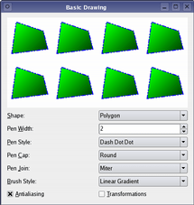

**Basic Drawing Example**

The [Basic Drawing](https://doc.qt.io/qt-6.2/qtwidgets-painting-basicdrawing-example.html) example shows how to display basic graphics primitives in a variety of styles using the QPainter class.

If you need to draw a complex shape, especially if you need to do so repeatedly, consider creating a QPainterPath and drawing it using drawPath().

**Painter Paths example**

The QPainterPath class provides a container for painting operations, enabling graphical shapes to be constructed and reused.

The [Painter Paths](https://doc.qt.io/qt-6.2/qtwidgets-painting-painterpaths-example.html) example shows how painter paths can be used to build complex shapes for rendering.

[figure not shown]

QPainter also provides the fillPath() function which fills the given QPainterPath with the given QBrush, and the strokePath() function that draws the outline of the given path (i.e. strokes the path).

See also the [Vector Deformation](https://doc.qt.io/qt-6.2/qtwidgets-painting-deform-example.html) example which shows how to use advanced vector techniques to draw text using a QPainterPath, the [Gradients](https://doc.qt.io/qt-6.2/qtwidgets-painting-gradients-example.html) example which shows the different types of gradients that are available in Qt, and the [Path Stroking](https://doc.qt.io/qt-6.2/qtwidgets-painting-pathstroke-example.html) example which shows Qt's built-in dash patterns and shows how custom patterns can be used to extend the range of available patterns.

[Vector Deformation](https://doc.qt.io/qt-6.2/qtwidgets-painting-deform-example.html)

[Gradients](https://doc.qt.io/qt-6.2/qtwidgets-painting-gradients-example.html)

[Path Stroking](https://doc.qt.io/qt-6.2/qtwidgets-painting-pathstroke-example.html)

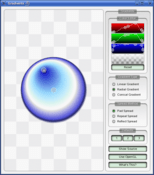

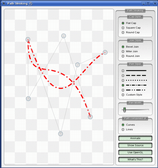

Text drawing is done using drawText(). When you need fine-grained positioning, boundingRect() tells you where a given drawText() command will draw.

### Drawing Pixmaps and Images

There are functions to draw pixmaps/images, namely drawPixmap(), drawImage() and drawTiledPixmap(). Both drawPixmap() and drawImage() produce the same result, except that drawPixmap() is faster on-screen while drawImage() may be faster on a QPrinter or other devices.

There is a drawPicture() function that draws the contents of an entire QPicture. The drawPicture() function is the only function that disregards all the painter's settings as QPicture has its own settings.

#### Drawing High Resolution Versions of Pixmaps and Images

High resolution versions of pixmaps have a *device pixel ratio* value larger than 1 (see QImageReader, QPixmap::devicePixelRatio()). Should it match the value of the underlying QPaintDevice, it is drawn directly onto the device with no additional transformation applied.

This is for example the case when drawing a QPixmap of 64x64 pixels size with a device pixel ratio of 2 onto a high DPI screen which also has a device pixel ratio of 2. Note that the pixmap is then effectively 32x32 pixels in *user space*. Code paths in Qt that calculate layout geometry based on the pixmap size will use this size. The net effect of this is that the pixmap is displayed as high DPI pixmap rather than a large pixmap.

### Rendering Quality

To get the optimal rendering result using QPainter, you should use the platform independent QImage as paint device; i.e. using QImage will ensure that the result has an identical pixel representation on any platform.

The QPainter class also provides a means of controlling the rendering quality through its RenderHint enum and the support for floating point precision: All the functions for drawing primitives has a floating point version. These are often used in combination with the QPainter::Antialiasing render hint.

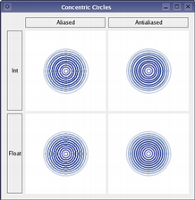

**Concentric Circles Example**

The [Concentric Circles](https://doc.qt.io/qt-6.2/qtwidgets-painting-concentriccircles-example.html) example shows the improved rendering quality that can be obtained using floating point precision and anti-aliasing when drawing custom widgets.

The application's main window displays several widgets which are drawn using the various combinations of precision and anti-aliasing.

The RenderHint enum specifies flags to QPainter that may or may not be respected by any given engine. QPainter::Antialiasing indicates that the engine should antialias edges of primitives if possible, QPainter::TextAntialiasing indicates that the engine should antialias text if possible, and the QPainter::SmoothPixmapTransform indicates that the engine should use a smooth pixmap transformation algorithm.

The renderHints() function returns a flag that specifies the rendering hints that are set for this painter. Use the setRenderHint() function to set or clear the currently set RenderHints.

### Coordinate Transformations

Normally, the QPainter operates on the device's own coordinate system (usually pixels), but QPainter has good support for coordinate transformations.

| nop | rotate() | scale() | translate() |
| --- | --- | --- | --- |

The most commonly used transformations are scaling, rotation, translation and shearing. Use the scale() function to scale the coordinate system by a given offset, the rotate() function to rotate it clockwise and translate() to translate it (i.e. adding a given offset to the points). You can also twist the coordinate system around the origin using the shear() function. See the [Affine Transformations](https://doc.qt.io/qt-6.2/qtwidgets-painting-affine-example.html) example for a visualization of a sheared coordinate system.

See also the [Transformations](https://doc.qt.io/qt-6.2/qtwidgets-painting-transformations-example.html) example which shows how transformations influence the way that QPainter renders graphics primitives. In particular it shows how the order of transformations affects the result.

**Affine Transformations Example**

The [Affine Transformations](https://doc.qt.io/qt-6.2/qtwidgets-painting-affine-example.html) example shows Qt's ability to perform affine transformations on painting operations. The demo also allows the user to experiment with the transformation operations and see the results immediately.

[figure not shown]

All the transformation operations operate on the transformation worldTransform(). A matrix transforms a point in the plane to another point. For more information about the transformation matrix, see the Coordinate System and QTransform documentation.

The setWorldTransform() function can replace or add to the currently set worldTransform(). The resetTransform() function resets any transformations that were made using translate(), scale(), shear(), rotate(), setWorldTransform(), setViewport() and setWindow() functions. The deviceTransform() returns the matrix that transforms from logical coordinates to device coordinates of the platform dependent paint device. The latter function is only needed when using platform painting commands on the platform dependent handle, and the platform does not do transformations nativly.

When drawing with QPainter, we specify points using logical coordinates which then are converted into the physical coordinates of the paint device. The mapping of the logical coordinates to the physical coordinates are handled by QPainter's combinedTransform(), a combination of viewport() and window() and worldTransform(). The viewport() represents the physical coordinates specifying an arbitrary rectangle, the window() describes the same rectangle in logical coordinates, and the worldTransform() is identical with the transformation matrix.

See also Coordinate System

### Clipping

QPainter can clip any drawing operation to a rectangle, a region, or a vector path. The current clip is available using the functions clipRegion() and clipPath(). Whether paths or regions are preferred (faster) depends on the underlying paintEngine(). For example, the QImage paint engine prefers paths while the X11 paint engine prefers regions. Setting a clip is done in the painters logical coordinates.

After QPainter's clipping, the paint device may also clip. For example, most widgets clip away the pixels used by child widgets, and most printers clip away an area near the edges of the paper. This additional clipping is not reflected by the return value of clipRegion() or hasClipping().

### Composition Modes

QPainter provides the CompositionMode enum which defines the Porter-Duff rules for digital image compositing; it describes a model for combining the pixels in one image, the source, with the pixels in another image, the destination.

The two most common forms of composition are Source and SourceOver. Source is used to draw opaque objects onto a paint device. In this mode, each pixel in the source replaces the corresponding pixel in the destination. In SourceOver composition mode, the source object is transparent and is drawn on top of the destination.

Note that composition transformation operates pixelwise. For that reason, there is a difference between using the graphic primitive itself and its bounding rectangle: The bounding rect contains pixels with alpha == 0 (i.e the pixels surrounding the primitive). These pixels will overwrite the other image's pixels, effectively clearing those, while the primitive only overwrites its own area.

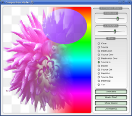

**Composition Modes Example**

The [Composition Modes](https://doc.qt.io/qt-6.2/qtwidgets-painting-composition-example.html) example, available in Qt's examples directory, allows you to experiment with the various composition modes and see the results immediately.

### Limitations

If you are using coordinates with Qt's raster-based paint engine, it is important to note that, while coordinates greater than +/- 2<sup>15</sup> can be used, any painting performed with coordinates outside this range is not guaranteed to be shown; the drawing may be clipped. This is due to the use of `short int` in the implementation.

The outlines generated by Qt's stroker are only an approximation when dealing with curved shapes. It is in most cases impossible to represent the outline of a bezier curve segment using another bezier curve segment, and so Qt approximates the curve outlines by using several smaller curves. For performance reasons there is a limit to how many curves Qt uses for these outlines, and thus when using large pen widths or scales the outline error increases. To generate outlines with smaller errors it is possible to use the QPainterPathStroker class, which has the setCurveThreshold member function which let's the user specify the error tolerance. Another workaround is to convert the paths to polygons first and then draw the polygons instead.

### Performance

QPainter is a rich framework that allows developers to do a great variety of graphical operations, such as gradients, composition modes and vector graphics. And QPainter can do this across a variety of different hardware and software stacks. Naturally the underlying combination of hardware and software has some implications for performance, and ensuring that every single operation is fast in combination with all the various combinations of composition modes, brushes, clipping, transformation, etc, is close to an impossible task because of the number of permutations. As a compromise we have selected a subset of the QPainter API and backends, where performance is guaranteed to be as good as we can sensibly get it for the given combination of hardware and software.

The backends we focus on as high-performance engines are:

- Raster - This backend implements all rendering in pure software and is always used to render into QImages. For optimal performance only use the format types QImage::Format_ARGB32_Premultiplied, QImage::Format_RGB32 or QImage::Format_RGB16. Any other format, including QImage::Format_ARGB32, has significantly worse performance. This engine is used by default for QWidget and QPixmap.
- OpenGL 2.0 (ES) - This backend is the primary backend for hardware accelerated graphics. It can be run on desktop machines and embedded devices supporting the OpenGL 2.0 or OpenGL/ES 2.0 specification. This includes most graphics chips produced in the last couple of years. The engine can be enabled by using QPainter onto a QOpenGLWidget.

These operations are:

- Simple transformations, meaning translation and scaling, pluss 0, 90, 180, 270 degree rotations.
- `drawPixmap()` in combination with simple transformations and opacity with non-smooth transformation mode (`QPainter::SmoothPixmapTransform` not enabled as a render hint).
- Rectangle fills with solid color, two-color linear gradients and simple transforms.
- Rectangular clipping with simple transformations and intersect clip.
- Composition Modes `QPainter::CompositionMode_Source` and QPainter::CompositionMode_SourceOver.
- Rounded rectangle filling using solid color and two-color linear gradients fills.
- 3x3 patched pixmaps, via qDrawBorderPixmap.

This list gives an indication of which features to safely use in an application where performance is critical. For certain setups, other operations may be fast too, but before making extensive use of them, it is recommended to benchmark and verify them on the system where the software will run in the end. There are also cases where expensive operations are ok to use, for instance when the result is cached in a QPixmap.

**See also** QPaintDevice, QPaintEngine, Qt SVG, [Basic Drawing Example](https://doc.qt.io/qt-6.2/qtwidgets-painting-basicdrawing-example.html), and Drawing Utility Functions.

## Member Type Documentation

### enum QPainter::CompositionMode

Defines the modes supported for digital image compositing. Composition modes are used to specify how the pixels in one image, the source, are merged with the pixel in another image, the destination.

Please note that the bitwise raster operation modes, denoted with a RasterOp prefix, are only natively supported in the X11 and raster paint engines. This means that the only way to utilize these modes on the Mac is via a QImage. The RasterOp denoted blend modes are *not* supported for pens and brushes with alpha components. Also, turning on the QPainter::Antialiasing render hint will effectively disable the RasterOp modes.

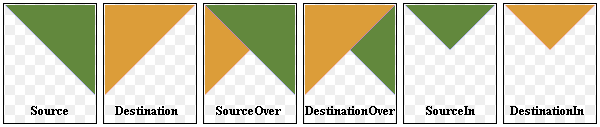

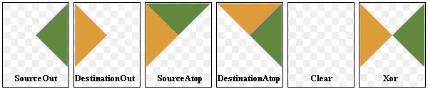

The most common type is SourceOver (often referred to as just alpha blending) where the source pixel is blended on top of the destination pixel in such a way that the alpha component of the source defines the translucency of the pixel.

Several composition modes require an alpha channel in the source or target images to have an effect. For optimal performance the image format Format_ARGB32_Premultiplied is preferred.

When a composition mode is set it applies to all painting operator, pens, brushes, gradients and pixmap/image drawing.

| Constant | Value | Description |
| --- | --- | --- |
| `QPainter::CompositionMode_SourceOver` | `0` | This is the default mode. The alpha of the source is used to blend the pixel on top of the destination. |
| `QPainter::CompositionMode_DestinationOver` | `1` | The alpha of the destination is used to blend it on top of the source pixels. This mode is the inverse of CompositionMode_SourceOver. |
| `QPainter::CompositionMode_Clear` | `2` | The pixels in the destination are cleared (set to fully transparent) independent of the source. |
| `QPainter::CompositionMode_Source` | `3` | The output is the source pixel. (This means a basic copy operation and is identical to SourceOver when the source pixel is opaque). |
| `QPainter::CompositionMode_Destination` | `4` | The output is the destination pixel. This means that the blending has no effect. This mode is the inverse of CompositionMode_Source. |
| `QPainter::CompositionMode_SourceIn` | `5` | The output is the source, where the alpha is reduced by that of the destination. |
| `QPainter::CompositionMode_DestinationIn` | `6` | The output is the destination, where the alpha is reduced by that of the source. This mode is the inverse of CompositionMode_SourceIn. |
| `QPainter::CompositionMode_SourceOut` | `7` | The output is the source, where the alpha is reduced by the inverse of destination. |
| `QPainter::CompositionMode_DestinationOut` | `8` | The output is the destination, where the alpha is reduced by the inverse of the source. This mode is the inverse of CompositionMode_SourceOut. |
| `QPainter::CompositionMode_SourceAtop` | `9` | The source pixel is blended on top of the destination, with the alpha of the source pixel reduced by the alpha of the destination pixel. |
| `QPainter::CompositionMode_DestinationAtop` | `10` | The destination pixel is blended on top of the source, with the alpha of the destination pixel is reduced by the alpha of the destination pixel. This mode is the inverse of CompositionMode_SourceAtop. |
| `QPainter::CompositionMode_Xor` | `11` | The source, whose alpha is reduced with the inverse of the destination alpha, is merged with the destination, whose alpha is reduced by the inverse of the source alpha. CompositionMode_Xor is not the … |
| `QPainter::CompositionMode_Plus` | `12` | Both the alpha and color of the source and destination pixels are added together. |
| `QPainter::CompositionMode_Multiply` | `13` | The output is the source color multiplied by the destination. Multiplying a color with white leaves the color unchanged, while multiplying a color with black produces black. |
| `QPainter::CompositionMode_Screen` | `14` | The source and destination colors are inverted and then multiplied. Screening a color with white produces white, whereas screening a color with black leaves the color unchanged. |
| `QPainter::CompositionMode_Overlay` | `15` | Multiplies or screens the colors depending on the destination color. The destination color is mixed with the source color to reflect the lightness or darkness of the destination. |
| `QPainter::CompositionMode_Darken` | `16` | The darker of the source and destination colors is selected. |
| `QPainter::CompositionMode_Lighten` | `17` | The lighter of the source and destination colors is selected. |
| `QPainter::CompositionMode_ColorDodge` | `18` | The destination color is brightened to reflect the source color. A black source color leaves the destination color unchanged. |
| `QPainter::CompositionMode_ColorBurn` | `19` | The destination color is darkened to reflect the source color. A white source color leaves the destination color unchanged. |
| `QPainter::CompositionMode_HardLight` | `20` | Multiplies or screens the colors depending on the source color. A light source color will lighten the destination color, whereas a dark source color will darken the destination color. |
| `QPainter::CompositionMode_SoftLight` | `21` | Darkens or lightens the colors depending on the source color. Similar to CompositionMode_HardLight. |
| `QPainter::CompositionMode_Difference` | `22` | Subtracts the darker of the colors from the lighter. Painting with white inverts the destination color, whereas painting with black leaves the destination color unchanged. |
| `QPainter::CompositionMode_Exclusion` | `23` | Similar to CompositionMode_Difference, but with a lower contrast. Painting with white inverts the destination color, whereas painting with black leaves the destination color unchanged. |
| `QPainter::RasterOp_SourceOrDestination` | `24` | Does a bitwise OR operation on the source and destination pixels (src OR dst). |
| `QPainter::RasterOp_SourceAndDestination` | `25` | Does a bitwise AND operation on the source and destination pixels (src AND dst). |
| `QPainter::RasterOp_SourceXorDestination` | `26` | Does a bitwise XOR operation on the source and destination pixels (src XOR dst). |
| `QPainter::RasterOp_NotSourceAndNotDestination` | `27` | Does a bitwise NOR operation on the source and destination pixels ((NOT src) AND (NOT dst)). |
| `QPainter::RasterOp_NotSourceOrNotDestination` | `28` | Does a bitwise NAND operation on the source and destination pixels ((NOT src) OR (NOT dst)). |
| `QPainter::RasterOp_NotSourceXorDestination` | `29` | Does a bitwise operation where the source pixels are inverted and then XOR'ed with the destination ((NOT src) XOR dst). |
| `QPainter::RasterOp_NotSource` | `30` | Does a bitwise operation where the source pixels are inverted (NOT src). |
| `QPainter::RasterOp_NotSourceAndDestination` | `31` | Does a bitwise operation where the source is inverted and then AND'ed with the destination ((NOT src) AND dst). |
| `QPainter::RasterOp_SourceAndNotDestination` | `32` | Does a bitwise operation where the source is AND'ed with the inverted destination pixels (src AND (NOT dst)). |
| `QPainter::RasterOp_NotSourceOrDestination` | `33` | Does a bitwise operation where the source is inverted and then OR'ed with the destination ((NOT src) OR dst). |
| `QPainter::RasterOp_ClearDestination` | `35` | The pixels in the destination are cleared (set to 0) independent of the source. |
| `QPainter::RasterOp_SetDestination` | `36` | The pixels in the destination are set (set to 1) independent of the source. |
| `QPainter::RasterOp_NotDestination` | `37` | Does a bitwise operation where the destination pixels are inverted (NOT dst). |
| `QPainter::RasterOp_SourceOrNotDestination` | `34` | Does a bitwise operation where the source is OR'ed with the inverted destination pixels (src OR (NOT dst)). |

**See also** compositionMode(), setCompositionMode(), Composition Modes, and [Image Composition Example](https://doc.qt.io/qt-6.2/qtwidgets-painting-imagecomposition-example.html).

### enum QPainter::PixmapFragmentHintflags QPainter::PixmapFragmentHints

| Constant | Value | Description |
| --- | --- | --- |
| `QPainter::OpaqueHint` | `0x01` | Indicates that the pixmap fragments to be drawn are opaque. Opaque fragments are potentially faster to draw. |

The PixmapFragmentHints type is a typedef for QFlags<PixmapFragmentHint>. It stores an OR combination of PixmapFragmentHint values.

**See also** QPainter::drawPixmapFragments() and QPainter::PixmapFragment.

### enum QPainter::RenderHintflags QPainter::RenderHints

Renderhints are used to specify flags to QPainter that may or may not be respected by any given engine.

| Constant | Value | Description |
| --- | --- | --- |
| `QPainter::Antialiasing` | `0x01` | Indicates that the engine should antialias edges of primitives if possible. |
| `QPainter::TextAntialiasing` | `0x02` | Indicates that the engine should antialias text if possible. To forcibly disable antialiasing for text, do not use this hint. Instead, set QFont::NoAntialias on your font's style strategy. |
| `QPainter::SmoothPixmapTransform` | `0x04` | Indicates that the engine should use a smooth pixmap transformation algorithm (such as bilinear) rather than nearest neighbor. |
| `QPainter::VerticalSubpixelPositioning` | `0x08` | Allow text to be positioned at fractions of pixels vertically as well as horizontally, if this is supported by the font engine. This is currently supported by Freetype on all platforms when the hintin… |
| `QPainter::LosslessImageRendering` | `0x40` | Use a lossless image rendering, whenever possible. Currently, this hint is only used when QPainter is employed to output a PDF file through QPrinter or QPdfWriter, where drawImage()/drawPixmap() calls… |

The RenderHints type is a typedef for QFlags<RenderHint>. It stores an OR combination of RenderHint values.

**See also** renderHints(), setRenderHint(), Rendering Quality, and [Concentric Circles Example](https://doc.qt.io/qt-6.2/qtwidgets-painting-concentriccircles-example.html).

## Member Function Documentation

### QPainter::QPainter(QPaintDevice **device*)

Constructs a painter that begins painting the paint *device* immediately.

This constructor is convenient for short-lived painters, e.g. in a QWidget::paintEvent() and should be used only once. The constructor calls begin() for you and the QPainter destructor automatically calls end().

Here's an example using begin() and end():

```
void MyWidget::paintEvent(QPaintEvent *)
{
    QPainter p;
    p.begin(this);
    p.drawLine(drawingCode);        // drawing code
    p.end();
}
```

The same example using this constructor:

```
void MyWidget::paintEvent(QPaintEvent *)
{
    QPainter p(this);
    p.drawLine(drawingCode);        // drawing code
}
```

Since the constructor cannot provide feedback when the initialization of the painter failed you should rather use begin() and end() to paint on external devices, e.g. printers.

**See also** begin() and end().

### QPainter::QPainter()

Constructs a painter.

**See also** begin() and end().

### QPainter::~QPainter()

Destroys the painter.

### const QBrush &QPainter::background() const

Returns the current background brush.

**See also** setBackground() and Settings.

### Qt::BGMode QPainter::backgroundMode() const

Returns the current background mode.

**See also** setBackgroundMode() and Settings.

### bool QPainter::begin(QPaintDevice **device*)

Begins painting the paint *device* and returns `true` if successful; otherwise returns `false`.

Notice that all painter settings (setPen(), setBrush() etc.) are reset to default values when begin() is called.

The errors that can occur are serious problems, such as these:

```
painter->begin(0); // impossible - paint device cannot be 0

QPixmap image(0, 0);
painter->begin(&image); // impossible - image.isNull() == true;

painter->begin(myWidget);
painter2->begin(myWidget); // impossible - only one painter at a time
```

Note that most of the time, you can use one of the constructors instead of begin(), and that end() is automatically done at destruction.

**Warning:** A paint device can only be painted by one painter at a time.

**Warning:** Painting on a QImage with the format QImage::Format_Indexed8 is not supported.

**See also** end() and QPainter().

### void QPainter::beginNativePainting()

Flushes the painting pipeline and prepares for the user issuing commands directly to the underlying graphics context. Must be followed by a call to endNativePainting().

Note that only the states the underlying paint engine changes will be reset to their respective default states. The states we reset may change from release to release. The following states are currently reset in the OpenGL 2 engine:

- blending is disabled
- the depth, stencil and scissor tests are disabled
- the active texture unit is reset to 0
- the depth mask, depth function and the clear depth are reset to their default values
- the stencil mask, stencil operation and stencil function are reset to their default values
- the current color is reset to solid white

If, for example, the OpenGL polygon mode is changed by the user inside a beginNativePaint()/endNativePainting() block, it will not be reset to the default state by endNativePainting(). Here is an example that shows intermixing of painter commands and raw OpenGL commands:

```
QPainter painter(this);
painter.fillRect(0, 0, 128, 128, Qt::green);
painter.beginNativePainting();

glEnable(GL_SCISSOR_TEST);
glScissor(0, 0, 64, 64);

glClearColor(1, 0, 0, 1);
glClear(GL_COLOR_BUFFER_BIT);

glDisable(GL_SCISSOR_TEST);

painter.endNativePainting();
```

**See also** endNativePainting().

### QRectF QPainter::boundingRect(const QRectF &*rectangle*, int *flags*, const QString &*text*)

Returns the bounding rectangle of the *text* as it will appear when drawn inside the given *rectangle* with the specified *flags* using the currently set font(); i.e the function tells you where the drawText() function will draw when given the same arguments.

If the *text* does not fit within the given *rectangle* using the specified *flags*, the function returns the required rectangle.

The *flags* argument is a bitwise OR of the following flags:

- Qt::AlignLeft
- Qt::AlignRight
- Qt::AlignHCenter
- Qt::AlignTop
- Qt::AlignBottom
- Qt::AlignVCenter
- Qt::AlignCenter
- Qt::TextSingleLine
- Qt::TextExpandTabs
- Qt::TextShowMnemonic
- Qt::TextWordWrap
- Qt::TextIncludeTrailingSpaces

If several of the horizontal or several of the vertical alignment flags are set, the resulting alignment is undefined.

**See also** drawText(), Qt::Alignment, and Qt::TextFlag.

### QRect QPainter::boundingRect(const QRect &*rectangle*, int *flags*, const QString &*text*)

This is an overloaded function.

Returns the bounding rectangle of the *text* as it will appear when drawn inside the given *rectangle* with the specified *flags* using the currently set font().

### QRect QPainter::boundingRect(int *x*, int *y*, int *w*, int *h*, int *flags*, const QString &*text*)

This is an overloaded function.

Returns the bounding rectangle of the given *text* as it will appear when drawn inside the rectangle beginning at the point (*x*, *y*) with width *w* and height *h*.

### QRectF QPainter::boundingRect(const QRectF &*rectangle*, const QString &*text*, const QTextOption &*option* = QTextOption())

This is an overloaded function.

Instead of specifying flags as a bitwise OR of the Qt::AlignmentFlag and Qt::TextFlag, this overloaded function takes an *option* argument. The QTextOption class provides a description of general rich text properties.

**See also** QTextOption.

### const QBrush &QPainter::brush() const

Returns the painter's current brush.

**See also** QPainter::setBrush() and Settings.

### QPoint QPainter::brushOrigin() const

Returns the currently set brush origin.

**See also** setBrushOrigin() and Settings.

### QRectF QPainter::clipBoundingRect() const

Returns the bounding rectangle of the current clip if there is a clip; otherwise returns an empty rectangle. Note that the clip region is given in logical coordinates.

The bounding rectangle is not guaranteed to be tight.

**See also** setClipRect(), setClipPath(), and setClipRegion().

### QPainterPath QPainter::clipPath() const

Returns the current clip path in logical coordinates.

**Warning:** QPainter does not store the combined clip explicitly as this is handled by the underlying QPaintEngine, so the path is recreated on demand and transformed to the current logical coordinate system. This is potentially an expensive operation.

**See also** setClipPath(), clipRegion(), and setClipping().

### QRegion QPainter::clipRegion() const

Returns the currently set clip region. Note that the clip region is given in logical coordinates.

**Warning:** QPainter does not store the combined clip explicitly as this is handled by the underlying QPaintEngine, so the path is recreated on demand and transformed to the current logical coordinate system. This is potentially an expensive operation.

**See also** setClipRegion(), clipPath(), and setClipping().

### QTransform QPainter::combinedTransform() const

Returns the transformation matrix combining the current window/viewport and world transformation.

**See also** setWorldTransform(), setWindow(), and setViewport().

### QPainter::CompositionMode QPainter::compositionMode() const

Returns the current composition mode.

**See also** CompositionMode and setCompositionMode().

### QPaintDevice *QPainter::device() const

Returns the paint device on which this painter is currently painting, or `nullptr` if the painter is not active.

**See also** isActive().

### const QTransform &QPainter::deviceTransform() const

Returns the matrix that transforms from logical coordinates to device coordinates of the platform dependent paint device.

This function is *only* needed when using platform painting commands on the platform dependent handle (Qt::HANDLE), and the platform does not do transformations nativly.

The QPaintEngine::PaintEngineFeature enum can be queried to determine whether the platform performs the transformations or not.

**See also** worldTransform() and QPaintEngine::hasFeature().

### void QPainter::drawArc(const QRectF &*rectangle*, int *startAngle*, int *spanAngle*)

Draws the arc defined by the given *rectangle*, *startAngle* and *spanAngle*.

The *startAngle* and *spanAngle* must be specified in 1/16th of a degree, i.e. a full circle equals 5760 (16 * 360). Positive values for the angles mean counter-clockwise while negative values mean the clockwise direction. Zero degrees is at the 3 o'clock position.

```
QRectF rectangle(10.0, 20.0, 80.0, 60.0);
int startAngle = 30 * 16;
int spanAngle = 120 * 16;

QPainter painter(this);
painter.drawArc(rectangle, startAngle, spanAngle);
```

**See also** drawPie(), drawChord(), and Coordinate System.

### void QPainter::drawArc(const QRect &*rectangle*, int *startAngle*, int *spanAngle*)

This is an overloaded function.

Draws the arc defined by the given *rectangle*, *startAngle* and *spanAngle*.

### void QPainter::drawArc(int *x*, int *y*, int *width*, int *height*, int *startAngle*, int *spanAngle*)

This is an overloaded function.

Draws the arc defined by the rectangle beginning at (*x*, *y*) with the specified *width* and *height*, and the given *startAngle* and *spanAngle*.

### void QPainter::drawChord(const QRectF &*rectangle*, int *startAngle*, int *spanAngle*)

Draws the chord defined by the given *rectangle*, *startAngle* and *spanAngle*. The chord is filled with the current brush().

The startAngle and spanAngle must be specified in 1/16th of a degree, i.e. a full circle equals 5760 (16 * 360). Positive values for the angles mean counter-clockwise while negative values mean the clockwise direction. Zero degrees is at the 3 o'clock position.

```
QRectF rectangle(10.0, 20.0, 80.0, 60.0);
int startAngle = 30 * 16;
int spanAngle = 120 * 16;

QPainter painter(this);
painter.drawChord(rect, startAngle, spanAngle);
```

**See also** drawArc(), drawPie(), and Coordinate System.

### void QPainter::drawChord(int *x*, int *y*, int *width*, int *height*, int *startAngle*, int *spanAngle*)

This is an overloaded function.

Draws the chord defined by the rectangle beginning at (*x*, *y*) with the specified *width* and *height*, and the given *startAngle* and *spanAngle*.

### void QPainter::drawChord(const QRect &*rectangle*, int *startAngle*, int *spanAngle*)

This is an overloaded function.

Draws the chord defined by the given *rectangle*, *startAngle* and *spanAngle*.

### void QPainter::drawConvexPolygon(const QPointF **points*, int *pointCount*)

Draws the convex polygon defined by the first *pointCount* points in the array *points* using the current pen.

```
static const QPointF points[4] = {
    QPointF(10.0, 80.0),
    QPointF(20.0, 10.0),
    QPointF(80.0, 30.0),
    QPointF(90.0, 70.0)
};

QPainter painter(this);
painter.drawConvexPolygon(points, 4);
```

The first point is implicitly connected to the last point, and the polygon is filled with the current brush(). If the supplied polygon is not convex, i.e. it contains at least one angle larger than 180 degrees, the results are undefined.

On some platforms (e.g. X11), the drawConvexPolygon() function can be faster than the drawPolygon() function.

**See also** drawPolygon(), drawPolyline(), and Coordinate System.

### void QPainter::drawConvexPolygon(const QPolygonF &*polygon*)

This is an overloaded function.

Draws the convex polygon defined by *polygon* using the current pen and brush.

### void QPainter::drawConvexPolygon(const QPoint **points*, int *pointCount*)

This is an overloaded function.

Draws the convex polygon defined by the first *pointCount* points in the array *points* using the current pen.

### void QPainter::drawConvexPolygon(const QPolygon &*polygon*)

This is an overloaded function.

Draws the convex polygon defined by *polygon* using the current pen and brush.

### void QPainter::drawEllipse(const QRectF &*rectangle*)

Draws the ellipse defined by the given *rectangle*.

A filled ellipse has a size of *rectangle*.size(). A stroked ellipse has a size of *rectangle*.size() plus the pen width.

```
QRectF rectangle(10.0, 20.0, 80.0, 60.0);

QPainter painter(this);
painter.drawEllipse(rectangle);
```

**See also** drawPie() and Coordinate System.

### void QPainter::drawEllipse(const QRect &*rectangle*)

This is an overloaded function.

Draws the ellipse defined by the given *rectangle*.

### void QPainter::drawEllipse(int *x*, int *y*, int *width*, int *height*)

This is an overloaded function.

Draws the ellipse defined by the rectangle beginning at (*x*, *y*) with the given *width* and *height*.

### void QPainter::drawEllipse(const QPointF &*center*, qreal *rx*, qreal *ry*)

This is an overloaded function.

Draws the ellipse positioned at *center* with radii *rx* and *ry*.

### void QPainter::drawEllipse(const QPoint &*center*, int *rx*, int *ry*)

This is an overloaded function.

Draws the ellipse positioned at *center* with radii *rx* and *ry*.

### void QPainter::drawGlyphRun(const QPointF &*position*, const [QGlyphRun](https://doc.qt.io/qt-6.2/qglyphrun.html) &*glyphs*)

Draws the glyphs represented by *glyphs* at *position*. The *position* gives the edge of the baseline for the string of glyphs. The glyphs will be retrieved from the font selected on *glyphs* and at offsets given by the positions in *glyphs*.

**See also** [QGlyphRun::setRawFont](https://doc.qt.io/qt-6.2/qglyphrun.html#setRawFont)(), [QGlyphRun::setPositions](https://doc.qt.io/qt-6.2/qglyphrun.html#setPositions)(), and [QGlyphRun::setGlyphIndexes](https://doc.qt.io/qt-6.2/qglyphrun.html#setGlyphIndexes)().

### void QPainter::drawImage(const QRectF &*target*, const QImage &*image*, const QRectF &*source*, Qt::ImageConversionFlags *flags* = Qt::AutoColor)

Draws the rectangular portion *source* of the given *image* into the *target* rectangle in the paint device.

**Note:** The image is scaled to fit the rectangle, if both the image and rectangle size disagree.

**Note:** See Drawing High Resolution Versions of Pixmaps and Images on how this is affected by QImage::devicePixelRatio().

If the image needs to be modified to fit in a lower-resolution result (e.g. converting from 32-bit to 8-bit), use the *flags* to specify how you would prefer this to happen.

```
QRectF target(10.0, 20.0, 80.0, 60.0);
QRectF source(0.0, 0.0, 70.0, 40.0);
QImage image(":/images/myImage.png");

QPainter painter(this);
painter.drawImage(target, image, source);
```

**See also** drawPixmap() and QImage::devicePixelRatio().

### void QPainter::drawImage(const QRect &*target*, const QImage &*image*, const QRect &*source*, Qt::ImageConversionFlags *flags* = Qt::AutoColor)

This is an overloaded function.

Draws the rectangular portion *source* of the given *image* into the *target* rectangle in the paint device.

**Note:** The image is scaled to fit the rectangle, if both the image and rectangle size disagree.

### void QPainter::drawImage(const QPointF &*point*, const QImage &*image*, const QRectF &*source*, Qt::ImageConversionFlags *flags* = Qt::AutoColor)

This is an overloaded function.

Draws the rectangular portion *source* of the given *image* with its origin at the given *point*.

### void QPainter::drawImage(const QPoint &*point*, const QImage &*image*, const QRect &*source*, Qt::ImageConversionFlags *flags* = Qt::AutoColor)

This is an overloaded function.

Draws the rectangular portion *source* of the given *image* with its origin at the given *point*.

### void QPainter::drawImage(const QRectF &*rectangle*, const QImage &*image*)

This is an overloaded function.

Draws the given *image* into the given *rectangle*.

**Note:** The image is scaled to fit the rectangle, if both the image and rectangle size disagree.

### void QPainter::drawImage(const QRect &*rectangle*, const QImage &*image*)

This is an overloaded function.

Draws the given *image* into the given *rectangle*.

**Note:** The image is scaled to fit the rectangle, if both the image and rectangle size disagree.

### void QPainter::drawImage(const QPointF &*point*, const QImage &*image*)

This is an overloaded function.

Draws the given *image* at the given *point*.

### void QPainter::drawImage(const QPoint &*point*, const QImage &*image*)

This is an overloaded function.

Draws the given *image* at the given *point*.

### void QPainter::drawImage(int *x*, int *y*, const QImage &*image*, int *sx* = 0, int *sy* = 0, int *sw* = -1, int *sh* = -1, Qt::ImageConversionFlags *flags* = Qt::AutoColor)

This is an overloaded function.

Draws an image at (*x*, *y*) by copying a part of *image* into the paint device.

(*x*, *y*) specifies the top-left point in the paint device that is to be drawn onto. (*sx*, *sy*) specifies the top-left point in *image* that is to be drawn. The default is (0, 0).

(*sw*, *sh*) specifies the size of the image that is to be drawn. The default, (0, 0) (and negative) means all the way to the bottom-right of the image.

### void QPainter::drawLine(const QLineF &*line*)

Draws a line defined by *line*.

```
QLineF line(10.0, 80.0, 90.0, 20.0);

QPainter(this);
painter.drawLine(line);
```

**See also** drawLines(), drawPolyline(), and Coordinate System.

### void QPainter::drawLine(const QLine &*line*)

This is an overloaded function.

Draws a line defined by *line*.

### void QPainter::drawLine(int *x1*, int *y1*, int *x2*, int *y2*)

This is an overloaded function.

Draws a line from (*x1*, *y1*) to (*x2*, *y2*).

### void QPainter::drawLine(const QPoint &*p1*, const QPoint &*p2*)

This is an overloaded function.

Draws a line from *p1* to *p2*.

### void QPainter::drawLine(const QPointF &*p1*, const QPointF &*p2*)

This is an overloaded function.

Draws a line from *p1* to *p2*.

### void QPainter::drawLines(const QLineF **lines*, int *lineCount*)

Draws the first *lineCount* lines in the array *lines* using the current pen.

**See also** drawLine() and drawPolyline().

### void QPainter::drawLines(const QList<QLineF> &*lines*)

This is an overloaded function.

Draws the set of lines defined by the list *lines* using the current pen and brush.

### void QPainter::drawLines(const QPointF **pointPairs*, int *lineCount*)

This is an overloaded function.

Draws the first *lineCount* lines in the array *pointPairs* using the current pen. The lines are specified as pairs of points so the number of entries in *pointPairs* must be at least *lineCount* * 2.

### void QPainter::drawLines(const QList<QPointF> &*pointPairs*)

This is an overloaded function.

Draws a line for each pair of points in the vector *pointPairs* using the current pen. If there is an odd number of points in the array, the last point will be ignored.

### void QPainter::drawLines(const QLine **lines*, int *lineCount*)

This is an overloaded function.

Draws the first *lineCount* lines in the array *lines* using the current pen.

### void QPainter::drawLines(const QList<QLine> &*lines*)

This is an overloaded function.

Draws the set of lines defined by the list *lines* using the current pen and brush.

### void QPainter::drawLines(const QPoint **pointPairs*, int *lineCount*)

This is an overloaded function.

Draws the first *lineCount* lines in the array *pointPairs* using the current pen.

### void QPainter::drawLines(const QList<QPoint> &*pointPairs*)

This is an overloaded function.

Draws a line for each pair of points in the vector *pointPairs* using the current pen.

### void QPainter::drawPath(const QPainterPath &*path*)

Draws the given painter *path* using the current pen for outline and the current brush for filling.

```
QPainterPath path;
path.moveTo(20, 80);
path.lineTo(20, 30);
path.cubicTo(80, 0, 50, 50, 80, 80);

QPainter painter(this);
painter.drawPath(path);
```

**See also** [the Painter Paths example](https://doc.qt.io/qt-6.2/qtwidgets-painting-painterpaths-example.html) and [the Vector Deformation example](https://doc.qt.io/qt-6.2/qtwidgets-painting-deform-example.html).

### void QPainter::drawPicture(const QPointF &*point*, const QPicture &*picture*)

Replays the given *picture* at the given *point*.

The QPicture class is a paint device that records and replays QPainter commands. A picture serializes the painter commands to an IO device in a platform-independent format. Everything that can be painted on a widget or pixmap can also be stored in a picture.

This function does exactly the same as QPicture::play() when called with *point* = QPointF(0, 0).

**Note:** The state of the painter is preserved by this function.

```
QPicture picture;
QPointF point(10.0, 20.0);
picture.load("drawing.pic");

QPainter painter(this);
painter.drawPicture(0, 0, picture);
```

**See also** QPicture::play().

### void QPainter::drawPicture(int *x*, int *y*, const QPicture &*picture*)

This is an overloaded function.

Draws the given *picture* at point (*x*, *y*).

### void QPainter::drawPicture(const QPoint &*point*, const QPicture &*picture*)

This is an overloaded function.

Replays the given *picture* at the given *point*.

### void QPainter::drawPie(const QRectF &*rectangle*, int *startAngle*, int *spanAngle*)

Draws a pie defined by the given *rectangle*, *startAngle* and *spanAngle*.

The pie is filled with the current brush().

The startAngle and spanAngle must be specified in 1/16th of a degree, i.e. a full circle equals 5760 (16 * 360). Positive values for the angles mean counter-clockwise while negative values mean the clockwise direction. Zero degrees is at the 3 o'clock position.

```
QRectF rectangle(10.0, 20.0, 80.0, 60.0);
int startAngle = 30 * 16;
int spanAngle = 120 * 16;

QPainter painter(this);
painter.drawPie(rectangle, startAngle, spanAngle);
```

**See also** drawEllipse(), drawChord(), and Coordinate System.

### void QPainter::drawPie(int *x*, int *y*, int *width*, int *height*, int *startAngle*, int *spanAngle*)

This is an overloaded function.

Draws the pie defined by the rectangle beginning at (*x*, *y*) with the specified *width* and *height*, and the given *startAngle* and *spanAngle*.

### void QPainter::drawPie(const QRect &*rectangle*, int *startAngle*, int *spanAngle*)

This is an overloaded function.

Draws a pie defined by the given *rectangle*, *startAngle* and and *spanAngle*.

### void QPainter::drawPixmap(const QRectF &*target*, const QPixmap &*pixmap*, const QRectF &*source*)

Draws the rectangular portion *source* of the given *pixmap* into the given *target* in the paint device.

**Note:** The pixmap is scaled to fit the rectangle, if both the pixmap and rectangle size disagree.

**Note:** See Drawing High Resolution Versions of Pixmaps and Images on how this is affected by QPixmap::devicePixelRatio().

```
QRectF target(10.0, 20.0, 80.0, 60.0);
QRectF source(0.0, 0.0, 70.0, 40.0);
QPixmap pixmap(":myPixmap.png");

QPainter(this);
painter.drawPixmap(target, pixmap, source);
```

If *pixmap* is a QBitmap it is drawn with the bits that are "set" using the pens color. If backgroundMode is Qt::OpaqueMode, the "unset" bits are drawn using the color of the background brush; if backgroundMode is Qt::TransparentMode, the "unset" bits are transparent. Drawing bitmaps with gradient or texture colors is not supported.

**See also** drawImage() and QPixmap::devicePixelRatio().

### void QPainter::drawPixmap(const QRect &*target*, const QPixmap &*pixmap*, const QRect &*source*)

This is an overloaded function.

Draws the rectangular portion *source* of the given *pixmap* into the given *target* in the paint device.

**Note:** The pixmap is scaled to fit the rectangle, if both the pixmap and rectangle size disagree.

### void QPainter::drawPixmap(int *x*, int *y*, int *w*, int *h*, const QPixmap &*pixmap*, int *sx*, int *sy*, int *sw*, int *sh*)

This is an overloaded function.

Draws the rectangular portion with the origin (*sx*, *sy*), width *sw* and height *sh*, of the given *pixmap* , at the point (*x*, *y*), with a width of *w* and a height of *h*. If sw or sh are equal to zero the width/height of the pixmap is used and adjusted by the offset sx/sy;

### void QPainter::drawPixmap(int *x*, int *y*, const QPixmap &*pixmap*, int *sx*, int *sy*, int *sw*, int *sh*)

This is an overloaded function.

Draws a pixmap at (*x*, *y*) by copying a part of the given *pixmap* into the paint device.

(*x*, *y*) specifies the top-left point in the paint device that is to be drawn onto. (*sx*, *sy*) specifies the top-left point in *pixmap* that is to be drawn. The default is (0, 0).

(*sw*, *sh*) specifies the size of the pixmap that is to be drawn. The default, (0, 0) (and negative) means all the way to the bottom-right of the pixmap.

### void QPainter::drawPixmap(const QPointF &*point*, const QPixmap &*pixmap*, const QRectF &*source*)

This is an overloaded function.

Draws the rectangular portion *source* of the given *pixmap* with its origin at the given *point*.

### void QPainter::drawPixmap(const QPoint &*point*, const QPixmap &*pixmap*, const QRect &*source*)

This is an overloaded function.

Draws the rectangular portion *source* of the given *pixmap* with its origin at the given *point*.

### void QPainter::drawPixmap(const QPointF &*point*, const QPixmap &*pixmap*)

This is an overloaded function.

Draws the given *pixmap* with its origin at the given *point*.

### void QPainter::drawPixmap(const QPoint &*point*, const QPixmap &*pixmap*)

This is an overloaded function.

Draws the given *pixmap* with its origin at the given *point*.

### void QPainter::drawPixmap(int *x*, int *y*, const QPixmap &*pixmap*)

This is an overloaded function.

Draws the given *pixmap* at position (*x*, *y*).

### void QPainter::drawPixmap(const QRect &*rectangle*, const QPixmap &*pixmap*)

This is an overloaded function.

Draws the given *pixmap* into the given *rectangle*.

**Note:** The pixmap is scaled to fit the rectangle, if both the pixmap and rectangle size disagree.

### void QPainter::drawPixmap(int *x*, int *y*, int *width*, int *height*, const QPixmap &*pixmap*)

This is an overloaded function.

Draws the *pixmap* into the rectangle at position (*x*, *y*) with the given *width* and *height*.

### void QPainter::drawPixmapFragments(const QPainter::PixmapFragment **fragments*, int *fragmentCount*, const QPixmap &*pixmap*, QPainter::PixmapFragmentHints *hints* = PixmapFragmentHints())

This function is used to draw *pixmap*, or a sub-rectangle of *pixmap*, at multiple positions with different scale, rotation and opacity. *fragments* is an array of *fragmentCount* elements specifying the parameters used to draw each pixmap fragment. The *hints* parameter can be used to pass in drawing hints.

This function is potentially faster than multiple calls to drawPixmap(), since the backend can optimize state changes.

**See also** QPainter::PixmapFragment and QPainter::PixmapFragmentHint.

### void QPainter::drawPoint(const QPointF &*position*)

Draws a single point at the given *position* using the current pen's color.

**See also** Coordinate System.

### void QPainter::drawPoint(const QPoint &*position*)

This is an overloaded function.

Draws a single point at the given *position* using the current pen's color.

### void QPainter::drawPoint(int *x*, int *y*)

This is an overloaded function.

Draws a single point at position (*x*, *y*).

### void QPainter::drawPoints(const QPointF **points*, int *pointCount*)

Draws the first *pointCount* points in the array *points* using the current pen's color.

**See also** Coordinate System.

### void QPainter::drawPoints(const QPolygonF &*points*)

This is an overloaded function.

Draws the points in the vector *points*.

### void QPainter::drawPoints(const QPoint **points*, int *pointCount*)

This is an overloaded function.

Draws the first *pointCount* points in the array *points* using the current pen's color.

### void QPainter::drawPoints(const QPolygon &*points*)

This is an overloaded function.

Draws the points in the vector *points*.

### void QPainter::drawPolygon(const QPointF **points*, int *pointCount*, Qt::FillRule *fillRule* = Qt::OddEvenFill)

Draws the polygon defined by the first *pointCount* points in the array *points* using the current pen and brush.

```
static const QPointF points[4] = {
    QPointF(10.0, 80.0),
    QPointF(20.0, 10.0),
    QPointF(80.0, 30.0),
    QPointF(90.0, 70.0)
};

QPainter painter(this);
painter.drawPolygon(points, 4);
```

The first point is implicitly connected to the last point, and the polygon is filled with the current brush().

If *fillRule* is Qt::WindingFill, the polygon is filled using the winding fill algorithm. If *fillRule* is Qt::OddEvenFill, the polygon is filled using the odd-even fill algorithm. See Qt::FillRule for a more detailed description of these fill rules.

**See also** drawConvexPolygon(), drawPolyline(), and Coordinate System.

### void QPainter::drawPolygon(const QPolygonF &*points*, Qt::FillRule *fillRule* = Qt::OddEvenFill)

This is an overloaded function.

Draws the polygon defined by the given *points* using the fill rule *fillRule*.

### void QPainter::drawPolygon(const QPoint **points*, int *pointCount*, Qt::FillRule *fillRule* = Qt::OddEvenFill)

This is an overloaded function.

Draws the polygon defined by the first *pointCount* points in the array *points*.

### void QPainter::drawPolygon(const QPolygon &*points*, Qt::FillRule *fillRule* = Qt::OddEvenFill)

This is an overloaded function.

Draws the polygon defined by the given *points* using the fill rule *fillRule*.

### void QPainter::drawPolyline(const QPointF **points*, int *pointCount*)

Draws the polyline defined by the first *pointCount* points in *points* using the current pen.

Note that unlike the drawPolygon() function the last point is *not* connected to the first, neither is the polyline filled.

```
static const QPointF points[3] = {
    QPointF(10.0, 80.0),
    QPointF(20.0, 10.0),
    QPointF(80.0, 30.0),
};

QPainter painter(this);
painter.drawPolyline(points, 3);
```

**See also** drawLines(), drawPolygon(), and Coordinate System.

### void QPainter::drawPolyline(const QPolygonF &*points*)

This is an overloaded function.

Draws the polyline defined by the given *points* using the current pen.

### void QPainter::drawPolyline(const QPoint **points*, int *pointCount*)

This is an overloaded function.

Draws the polyline defined by the first *pointCount* points in *points* using the current pen.

### void QPainter::drawPolyline(const QPolygon &*points*)

This is an overloaded function.

Draws the polyline defined by the given *points* using the current pen.

### void QPainter::drawRect(const QRectF &*rectangle*)

Draws the current *rectangle* with the current pen and brush.

A filled rectangle has a size of *rectangle*.size(). A stroked rectangle has a size of *rectangle*.size() plus the pen width.

```
QRectF rectangle(10.0, 20.0, 80.0, 60.0);

QPainter painter(this);
painter.drawRect(rectangle);
```

**See also** drawRects(), drawPolygon(), and Coordinate System.

### void QPainter::drawRect(int *x*, int *y*, int *width*, int *height*)

This is an overloaded function.

Draws a rectangle with upper left corner at (*x*, *y*) and with the given *width* and *height*.

### void QPainter::drawRect(const QRect &*rectangle*)

This is an overloaded function.

Draws the current *rectangle* with the current pen and brush.

### void QPainter::drawRects(const QRectF **rectangles*, int *rectCount*)

Draws the first *rectCount* of the given *rectangles* using the current pen and brush.

**See also** drawRect().

### void QPainter::drawRects(const QList<QRectF> &*rectangles*)

This is an overloaded function.

Draws the given *rectangles* using the current pen and brush.

### void QPainter::drawRects(const QRect **rectangles*, int *rectCount*)

This is an overloaded function.

Draws the first *rectCount* of the given *rectangles* using the current pen and brush.

### void QPainter::drawRects(const QList<QRect> &*rectangles*)

This is an overloaded function.

Draws the given *rectangles* using the current pen and brush.

### void QPainter::drawRoundedRect(const QRectF &*rect*, qreal *xRadius*, qreal *yRadius*, Qt::SizeMode *mode* = Qt::AbsoluteSize)

Draws the given rectangle *rect* with rounded corners.

The *xRadius* and *yRadius* arguments specify the radii of the ellipses defining the corners of the rounded rectangle. When *mode* is Qt::RelativeSize, *xRadius* and *yRadius* are specified in percentage of half the rectangle's width and height respectively, and should be in the range 0.0 to 100.0.

A filled rectangle has a size of rect.size(). A stroked rectangle has a size of rect.size() plus the pen width.

```
QRectF rectangle(10.0, 20.0, 80.0, 60.0);

QPainter painter(this);
painter.drawRoundedRect(rectangle, 20.0, 15.0);
```

**See also** drawRect() and QPen.

### void QPainter::drawRoundedRect(int *x*, int *y*, int *w*, int *h*, qreal *xRadius*, qreal *yRadius*, Qt::SizeMode *mode* = Qt::AbsoluteSize)

This is an overloaded function.

Draws the given rectangle *x*, *y*, *w*, *h* with rounded corners.

### void QPainter::drawRoundedRect(const QRect &*rect*, qreal *xRadius*, qreal *yRadius*, Qt::SizeMode *mode* = Qt::AbsoluteSize)

This is an overloaded function.

Draws the given rectangle *rect* with rounded corners.

### void QPainter::drawStaticText(const QPointF &*topLeftPosition*, const QStaticText &*staticText*)

Draws the given *staticText* at the given *topLeftPosition*.

The text will be drawn using the font and the transformation set on the painter. If the font and/or transformation set on the painter are different from the ones used to initialize the layout of the QStaticText, then the layout will have to be recalculated. Use QStaticText::prepare() to initialize *staticText* with the font and transformation with which it will later be drawn.

If *topLeftPosition* is not the same as when *staticText* was initialized, or when it was last drawn, then there will be a slight overhead when translating the text to its new position.

**Note:** If the painter's transformation is not affine, then *staticText* will be drawn using regular calls to drawText(), losing any potential for performance improvement.

**Note:** The y-position is used as the top of the font.

**See also** QStaticText.

### void QPainter::drawStaticText(const QPoint &*topLeftPosition*, const QStaticText &*staticText*)

This is an overloaded function.

Draws the *staticText* at the *topLeftPosition*.

**Note:** The y-position is used as the top of the font.

### void QPainter::drawStaticText(int *left*, int *top*, const QStaticText &*staticText*)

This is an overloaded function.

Draws the *staticText* at coordinates *left* and *top*.

**Note:** The y-position is used as the top of the font.

### void QPainter::drawText(const QRectF &*rectangle*, int *flags*, const QString &*text*, QRectF **boundingRect* = nullptr)

This is an overloaded function.

Draws the given *text* within the provided *rectangle*. The *rectangle* along with alignment *flags* defines the anchors for the *text*.

```
QPainter painter(this);
painter.drawText(rect, Qt::AlignCenter, tr("Qt\nProject"));
```

```
QPainter painter(this);
QFont font = painter.font();
font.setPixelSize(48);
painter.setFont(font);

const QRect rectangle = QRect(0, 0, 100, 50);
QRect boundingRect;
painter.drawText(rectangle, 0, tr("Hello"), &boundingRect);

QPen pen = painter.pen();
pen.setStyle(Qt::DotLine);
painter.setPen(pen);
painter.drawRect(boundingRect.adjusted(0, 0, -pen.width(), -pen.width()));

pen.setStyle(Qt::DashLine);
painter.setPen(pen);
painter.drawRect(rectangle.adjusted(0, 0, -pen.width(), -pen.width()));
```

The *flags* argument is a bitwise OR of the following flags:

- Qt::AlignLeft
- Qt::AlignRight
- Qt::AlignHCenter
- Qt::AlignJustify
- Qt::AlignTop
- Qt::AlignBottom
- Qt::AlignVCenter
- Qt::AlignCenter
- Qt::TextDontClip
- Qt::TextSingleLine
- Qt::TextExpandTabs
- Qt::TextShowMnemonic
- Qt::TextWordWrap
- Qt::TextIncludeTrailingSpaces

By default, QPainter draws text anti-aliased.

**Note:** The y-coordinate of *rectangle* is used as the top of the font.

**See also** Qt::AlignmentFlag, Qt::TextFlag, boundingRect(), and layoutDirection().

### void QPainter::drawText(const QPointF &*position*, const QString &*text*)

Draws the given *text* with the currently defined text direction, beginning at the given *position*.

This function does not handle the newline character (\n), as it cannot break text into multiple lines, and it cannot display the newline character. Use the QPainter::drawText() overload that takes a rectangle instead if you want to draw multiple lines of text with the newline character, or if you want the text to be wrapped.

By default, QPainter draws text anti-aliased.

**Note:** The y-position is used as the baseline of the font.

**See also** setFont() and setPen().

### void QPainter::drawText(const QPoint &*position*, const QString &*text*)

This is an overloaded function.

Draws the given *text* with the currently defined text direction, beginning at the given *position*.

By default, QPainter draws text anti-aliased.

**Note:** The y-position is used as the baseline of the font.

**See also** setFont() and setPen().

### void QPainter::drawText(int *x*, int *y*, const QString &*text*)

This is an overloaded function.

Draws the given *text* at position (*x*, *y*), using the painter's currently defined text direction.

By default, QPainter draws text anti-aliased.

**Note:** The y-position is used as the baseline of the font.

**See also** setFont() and setPen().

### void QPainter::drawText(const QRect &*rectangle*, int *flags*, const QString &*text*, QRect **boundingRect* = nullptr)

This is an overloaded function.

Draws the given *text* within the provided *rectangle* according to the specified *flags*.

```
QPainter painter(this);
QFont font = painter.font();
font.setPixelSize(48);
painter.setFont(font);

const QRect rectangle = QRect(0, 0, 100, 50);
QRect boundingRect;
painter.drawText(rectangle, 0, tr("Hello"), &boundingRect);

QPen pen = painter.pen();
pen.setStyle(Qt::DotLine);
painter.setPen(pen);
painter.drawRect(boundingRect.adjusted(0, 0, -pen.width(), -pen.width()));

pen.setStyle(Qt::DashLine);
painter.setPen(pen);
painter.drawRect(rectangle.adjusted(0, 0, -pen.width(), -pen.width()));
```

By default, QPainter draws text anti-aliased.

**Note:** The y-coordinate of *rectangle* is used as the top of the font.

**See also** setFont() and setPen().

### void QPainter::drawText(int *x*, int *y*, int *width*, int *height*, int *flags*, const QString &*text*, QRect **boundingRect* = nullptr)

This is an overloaded function.

Draws the given *text* within the rectangle with origin (*x*, *y*), *width* and *height*.

```
QPainter painter(this);
QFont font = painter.font();
font.setPixelSize(48);
painter.setFont(font);

const QRect rectangle = QRect(0, 0, 100, 50);
QRect boundingRect;
painter.drawText(rectangle, 0, tr("Hello"), &boundingRect);

QPen pen = painter.pen();
pen.setStyle(Qt::DotLine);
painter.setPen(pen);
painter.drawRect(boundingRect.adjusted(0, 0, -pen.width(), -pen.width()));

pen.setStyle(Qt::DashLine);
painter.setPen(pen);
painter.drawRect(rectangle.adjusted(0, 0, -pen.width(), -pen.width()));
```

The *flags* argument is a bitwise OR of the following flags:

- Qt::AlignLeft
- Qt::AlignRight
- Qt::AlignHCenter
- Qt::AlignJustify
- Qt::AlignTop
- Qt::AlignBottom
- Qt::AlignVCenter
- Qt::AlignCenter
- Qt::TextSingleLine
- Qt::TextExpandTabs
- Qt::TextShowMnemonic
- Qt::TextWordWrap

By default, QPainter draws text anti-aliased.

**Note:** The y-position is used as the top of the font.

**See also** Qt::AlignmentFlag, Qt::TextFlag, setFont(), and setPen().

### void QPainter::drawText(const QRectF &*rectangle*, const QString &*text*, const QTextOption &*option* = QTextOption())

This is an overloaded function.

Draws the given *text* in the *rectangle* specified using the *option* to control its positioning, direction, and orientation. The options given in *option* override those set on the QPainter object itself.

By default, QPainter draws text anti-aliased.

**Note:** The y-coordinate of *rectangle* is used as the top of the font.

**See also** setFont() and setPen().

### void QPainter::drawTiledPixmap(const QRectF &*rectangle*, const QPixmap &*pixmap*, const QPointF &*position* = QPointF())

Draws a tiled *pixmap*, inside the given *rectangle* with its origin at the given *position*.

Calling drawTiledPixmap() is similar to calling drawPixmap() several times to fill (tile) an area with a pixmap, but is potentially much more efficient depending on the underlying window system.

drawTiledPixmap() will produce the same visual tiling pattern on high-dpi displays (with devicePixelRatio > 1), compared to normal- dpi displays. Set the devicePixelRatio on the *pixmap* to control the tile size. For example, setting it to 2 halves the tile width and height (on both 1x and 2x displays), and produces high-resolution output on 2x displays.

The *position* offset is always in the painter coordinate system, indepentent of display devicePixelRatio.

**See also** drawPixmap().

### void QPainter::drawTiledPixmap(int *x*, int *y*, int *width*, int *height*, const QPixmap &*pixmap*, int *sx* = 0, int *sy* = 0)

This is an overloaded function.

Draws a tiled *pixmap* in the specified rectangle.

(*x*, *y*) specifies the top-left point in the paint device that is to be drawn onto; with the given *width* and *height*. (*sx*, *sy*) specifies the top-left point in the *pixmap* that is to be drawn; this defaults to (0, 0).

### void QPainter::drawTiledPixmap(const QRect &*rectangle*, const QPixmap &*pixmap*, const QPoint &*position* = QPoint())

This is an overloaded function.

Draws a tiled *pixmap*, inside the given *rectangle* with its origin at the given *position*.

### bool QPainter::end()

Ends painting. Any resources used while painting are released. You don't normally need to call this since it is called by the destructor.

Returns `true` if the painter is no longer active; otherwise returns `false`.

**See also** begin() and isActive().

### void QPainter::endNativePainting()

Restores the painter after manually issuing native painting commands. Lets the painter restore any native state that it relies on before calling any other painter commands.

**See also** beginNativePainting().

### void QPainter::eraseRect(const QRectF &*rectangle*)

Erases the area inside the given *rectangle*. Equivalent to calling

```
fillRect(rectangle, background());
```

**See also** fillRect().

### void QPainter::eraseRect(int *x*, int *y*, int *width*, int *height*)

This is an overloaded function.

Erases the area inside the rectangle beginning at (*x*, *y*) with the given *width* and *height*.

### void QPainter::eraseRect(const QRect &*rectangle*)

This is an overloaded function.

Erases the area inside the given *rectangle*.

### void QPainter::fillPath(const QPainterPath &*path*, const QBrush &*brush*)

Fills the given *path* using the given *brush*. The outline is not drawn.

Alternatively, you can specify a QColor instead of a QBrush; the QBrush constructor (taking a QColor argument) will automatically create a solid pattern brush.

**See also** drawPath().

### void QPainter::fillRect(const QRectF &*rectangle*, const QBrush &*brush*)

Fills the given *rectangle* with the *brush* specified.

Alternatively, you can specify a QColor instead of a QBrush; the QBrush constructor (taking a QColor argument) will automatically create a solid pattern brush.

**See also** drawRect().

### void QPainter::fillRect(int *x*, int *y*, int *width*, int *height*, const QBrush &*brush*)

This is an overloaded function.

Fills the rectangle beginning at (*x*, *y*) with the given *width* and *height*, using the given *brush*.

### void QPainter::fillRect(const QRect &*rectangle*, const QBrush &*brush*)

This is an overloaded function.

Fills the given *rectangle* with the specified *brush*.

### void QPainter::fillRect(const QRectF &*rectangle*, const QColor &*color*)

This is an overloaded function.

Fills the given *rectangle* with the *color* specified.

### void QPainter::fillRect(int *x*, int *y*, int *width*, int *height*, const QColor &*color*)

This is an overloaded function.

Fills the rectangle beginning at (*x*, *y*) with the given *width* and *height*, using the given *color*.

### void QPainter::fillRect(const QRect &*rectangle*, const QColor &*color*)

This is an overloaded function.

Fills the given *rectangle* with the *color* specified.

### void QPainter::fillRect(int *x*, int *y*, int *width*, int *height*, Qt::GlobalColor *color*)

This is an overloaded function.

Fills the rectangle beginning at (*x*, *y*) with the given *width* and *height*, using the given *color*.

### void QPainter::fillRect(const QRect &*rectangle*, Qt::GlobalColor *color*)

This is an overloaded function.

Fills the given *rectangle* with the specified *color*.

### void QPainter::fillRect(const QRectF &*rectangle*, Qt::GlobalColor *color*)

This is an overloaded function.

Fills the given *rectangle* with the specified *color*.

### void QPainter::fillRect(int *x*, int *y*, int *width*, int *height*, Qt::BrushStyle *style*)

This is an overloaded function.

Fills the rectangle beginning at (*x*, *y*) with the given *width* and *height*, using the brush *style* specified.

### void QPainter::fillRect(const QRect &*rectangle*, Qt::BrushStyle *style*)

This is an overloaded function.

Fills the given *rectangle* with the brush *style* specified.

### void QPainter::fillRect(const QRectF &*rectangle*, Qt::BrushStyle *style*)

This is an overloaded function.

Fills the given *rectangle* with the brush *style* specified.

### `[since 5.12]`void QPainter::fillRect(int *x*, int *y*, int *width*, int *height*, QGradient::Preset *preset*)

This is an overloaded function.

Fills the rectangle beginning at (*x*, *y*) with the given *width* and *height*, using the given gradient *preset*.

This function was introduced in Qt 5.12.

### `[since 5.12]`void QPainter::fillRect(const QRect &*rectangle*, QGradient::Preset *preset*)

This is an overloaded function.

Fills the given *rectangle* with the specified gradient *preset*.

This function was introduced in Qt 5.12.

### `[since 5.12]`void QPainter::fillRect(const QRectF &*rectangle*, QGradient::Preset *preset*)

This is an overloaded function.

Fills the given *rectangle* with the specified gradient *preset*.

This function was introduced in Qt 5.12.

### const QFont &QPainter::font() const

Returns the currently set font used for drawing text.

**See also** setFont(), drawText(), and Settings.

### QFontInfo QPainter::fontInfo() const

Returns the font info for the painter if the painter is active. Otherwise, the return value is undefined.

**See also** font(), isActive(), and Settings.

### QFontMetrics QPainter::fontMetrics() const

Returns the font metrics for the painter if the painter is active. Otherwise, the return value is undefined.

**See also** font(), isActive(), and Settings.

### bool QPainter::hasClipping() const

Returns `true` if clipping has been set; otherwise returns `false`.

**See also** setClipping() and Clipping.

### bool QPainter::isActive() const

Returns `true` if begin() has been called and end() has not yet been called; otherwise returns `false`.

**See also** begin() and QPaintDevice::paintingActive().

### Qt::LayoutDirection QPainter::layoutDirection() const

Returns the layout direction used by the painter when drawing text.

**See also** QTextOption::textDirection(), setLayoutDirection(), drawText(), and Settings.

### qreal QPainter::opacity() const

Returns the opacity of the painter. The default value is 1.

**See also** setOpacity().

### QPaintEngine *QPainter::paintEngine() const

Returns the paint engine that the painter is currently operating on if the painter is active; otherwise 0.

**See also** isActive().

### const QPen &QPainter::pen() const

Returns the painter's current pen.

**See also** setPen() and Settings.

### QPainter::RenderHints QPainter::renderHints() const

Returns a flag that specifies the rendering hints that are set for this painter.

**See also** setRenderHints(), testRenderHint(), and Rendering Quality.

### void QPainter::resetTransform()

Resets any transformations that were made using translate(), scale(), shear(), rotate(), setWorldTransform(), setViewport() and setWindow().

**See also** Coordinate Transformations.

### void QPainter::restore()

Restores the current painter state (pops a saved state off the stack).

**See also** save().

### void QPainter::rotate(qreal *angle*)

Rotates the coordinate system clockwise. The given *angle* parameter is in degrees.

**See also** setWorldTransform() and Coordinate Transformations.

### void QPainter::save()

Saves the current painter state (pushes the state onto a stack). A save() must be followed by a corresponding restore(); the end() function unwinds the stack.

**See also** restore().

### void QPainter::scale(qreal *sx*, qreal *sy*)

Scales the coordinate system by (*sx*, *sy*).

**See also** setWorldTransform() and Coordinate Transformations.

### void QPainter::setBackground(const QBrush &*brush*)

Sets the background brush of the painter to the given *brush*.

The background brush is the brush that is filled in when drawing opaque text, stippled lines and bitmaps. The background brush has no effect in transparent background mode (which is the default).

**See also** background(), setBackgroundMode(), and Settings.

### void QPainter::setBackgroundMode(Qt::BGMode *mode*)

Sets the background mode of the painter to the given *mode*

Qt::TransparentMode (the default) draws stippled lines and text without setting the background pixels. Qt::OpaqueMode fills these space with the current background color.

Note that in order to draw a bitmap or pixmap transparently, you must use QPixmap::setMask().

**See also** backgroundMode(), setBackground(), and Settings.

### void QPainter::setBrush(const QBrush &*brush*)

Sets the painter's brush to the given *brush*.

The painter's brush defines how shapes are filled.

**See also** brush() and Settings.

### void QPainter::setBrush(Qt::BrushStyle *style*)

This is an overloaded function.

Sets the painter's brush to black color and the specified *style*.

### void QPainter::setBrushOrigin(const QPointF &*position*)

Sets the brush origin to *position*.

The brush origin specifies the (0, 0) coordinate of the painter's brush.

Note that while the brushOrigin() was necessary to adopt the parent's background for a widget in Qt 3, this is no longer the case since the Qt 4 painter doesn't paint the background unless you explicitly tell it to do so by setting the widget's autoFillBackground property to true.

**See also** brushOrigin() and Settings.

### void QPainter::setBrushOrigin(int *x*, int *y*)

This is an overloaded function.

Sets the brush's origin to point (*x*, *y*).

### void QPainter::setBrushOrigin(const QPoint &*position*)

This is an overloaded function.

Sets the brush's origin to the given *position*.

### void QPainter::setClipPath(const QPainterPath &*path*, Qt::ClipOperation *operation* = Qt::ReplaceClip)

Enables clipping, and sets the clip path for the painter to the given *path*, with the clip *operation*.

Note that the clip path is specified in logical (painter) coordinates.

**See also** clipPath(), clipRegion(), and Clipping.

### void QPainter::setClipRect(const QRectF &*rectangle*, Qt::ClipOperation *operation* = Qt::ReplaceClip)

Enables clipping, and sets the clip region to the given *rectangle* using the given clip *operation*. The default operation is to replace the current clip rectangle.

Note that the clip rectangle is specified in logical (painter) coordinates.

**See also** clipRegion(), setClipping(), and Clipping.

### void QPainter::setClipRect(const QRect &*rectangle*, Qt::ClipOperation *operation* = Qt::ReplaceClip)

This is an overloaded function.

Enables clipping, and sets the clip region to the given *rectangle* using the given clip *operation*.

### void QPainter::setClipRect(int *x*, int *y*, int *width*, int *height*, Qt::ClipOperation *operation* = Qt::ReplaceClip)

Enables clipping, and sets the clip region to the rectangle beginning at (*x*, *y*) with the given *width* and *height*.

### void QPainter::setClipRegion(const QRegion &*region*, Qt::ClipOperation *operation* = Qt::ReplaceClip)

Sets the clip region to the given *region* using the specified clip *operation*. The default clip operation is to replace the current clip region.

Note that the clip region is given in logical coordinates.

**See also** clipRegion(), setClipRect(), and Clipping.

### void QPainter::setClipping(bool *enable*)

Enables clipping if *enable* is true, or disables clipping if *enable* is false.

**See also** hasClipping() and Clipping.

### void QPainter::setCompositionMode(QPainter::CompositionMode *mode*)

Sets the composition mode to the given *mode*.

**Warning:** Only a QPainter operating on a QImage fully supports all composition modes. The RasterOp modes are supported for X11 as described in compositionMode().

**See also** compositionMode().

### void QPainter::setFont(const QFont &*font*)

Sets the painter's font to the given *font*.

This font is used by subsequent drawText() functions. The text color is the same as the pen color.

If you set a font that isn't available, Qt finds a close match. font() will return what you set using setFont() and fontInfo() returns the font actually being used (which may be the same).

**See also** font(), drawText(), and Settings.

### void QPainter::setLayoutDirection(Qt::LayoutDirection *direction*)

Sets the layout direction used by the painter when drawing text, to the specified *direction*.

The default is Qt::LayoutDirectionAuto, which will implicitly determine the direction from the text drawn.

**See also** QTextOption::setTextDirection(), layoutDirection(), drawText(), and Settings.

### void QPainter::setOpacity(qreal *opacity*)

Sets the opacity of the painter to *opacity*. The value should be in the range 0.0 to 1.0, where 0.0 is fully transparent and 1.0 is fully opaque.

Opacity set on the painter will apply to all drawing operations individually.

**See also** opacity().

### void QPainter::setPen(const QPen &*pen*)

Sets the painter's pen to be the given *pen*.

The *pen* defines how to draw lines and outlines, and it also defines the text color.

**See also** pen() and Settings.

### void QPainter::setPen(const QColor &*color*)

This is an overloaded function.

Sets the painter's pen to have style Qt::SolidLine, width 1 and the specified *color*.

### void QPainter::setPen(Qt::PenStyle *style*)

This is an overloaded function.

Sets the painter's pen to have the given *style*, width 1 and black color.

### void QPainter::setRenderHint(QPainter::RenderHint *hint*, bool *on* = true)

Sets the given render *hint* on the painter if *on* is true; otherwise clears the render hint.

**See also** setRenderHints(), renderHints(), and Rendering Quality.

### void QPainter::setRenderHints(QPainter::RenderHints *hints*, bool *on* = true)

Sets the given render *hints* on the painter if *on* is true; otherwise clears the render hints.

**See also** setRenderHint(), renderHints(), and Rendering Quality.

### void QPainter::setTransform(const QTransform &*transform*, bool *combine* = false)

Sets the world transformation matrix. If *combine* is true, the specified *transform* is combined with the current matrix; otherwise it replaces the current matrix.

**See also** transform() and setWorldTransform().

### void QPainter::setViewTransformEnabled(bool *enable*)

Enables view transformations if *enable* is true, or disables view transformations if *enable* is false.

**See also** viewTransformEnabled() and Window-Viewport Conversion.

### void QPainter::setViewport(const QRect &*rectangle*)

Sets the painter's viewport rectangle to the given *rectangle*, and enables view transformations.

The viewport rectangle is part of the view transformation. The viewport specifies the device coordinate system. Its sister, the window(), specifies the logical coordinate system.

The default viewport rectangle is the same as the device's rectangle.

**See also** viewport(), viewTransformEnabled(), and Window-Viewport Conversion.

### void QPainter::setViewport(int *x*, int *y*, int *width*, int *height*)

This is an overloaded function.

Sets the painter's viewport rectangle to be the rectangle beginning at (*x*, *y*) with the given *width* and *height*.

### void QPainter::setWindow(const QRect &*rectangle*)

Sets the painter's window to the given *rectangle*, and enables view transformations.

The window rectangle is part of the view transformation. The window specifies the logical coordinate system. Its sister, the viewport(), specifies the device coordinate system.

The default window rectangle is the same as the device's rectangle.

**See also** window(), viewTransformEnabled(), and Window-Viewport Conversion.

### void QPainter::setWindow(int *x*, int *y*, int *width*, int *height*)

This is an overloaded function.

Sets the painter's window to the rectangle beginning at (*x*, *y*) and the given *width* and *height*.

### void QPainter::setWorldMatrixEnabled(bool *enable*)

Enables transformations if *enable* is true, or disables transformations if *enable* is false. The world transformation matrix is not changed.

**See also** worldMatrixEnabled(), worldTransform(), and Coordinate Transformations.

### void QPainter::setWorldTransform(const QTransform &*matrix*, bool *combine* = false)

Sets the world transformation matrix. If *combine* is true, the specified *matrix* is combined with the current matrix; otherwise it replaces the current matrix.

**See also** worldTransform(), transform(), and setTransform().

### void QPainter::shear(qreal *sh*, qreal *sv*)

Shears the coordinate system by (*sh*, *sv*).

**See also** setWorldTransform() and Coordinate Transformations.

### void QPainter::strokePath(const QPainterPath &*path*, const QPen &*pen*)

Draws the outline (strokes) the path *path* with the pen specified by *pen*

**See also** fillPath() and Drawing.

### bool QPainter::testRenderHint(QPainter::RenderHint *hint*) const

Returns `true` if *hint* is set; otherwise returns `false`.

**See also** renderHints() and setRenderHint().

### const QTransform &QPainter::transform() const

Alias for worldTransform(). Returns the world transformation matrix.

**See also** setTransform() and worldTransform().

### void QPainter::translate(const QPointF &*offset*)

Translates the coordinate system by the given *offset*; i.e. the given *offset* is added to points.

**See also** setWorldTransform() and Coordinate Transformations.

### void QPainter::translate(const QPoint &*offset*)

This is an overloaded function.

Translates the coordinate system by the given *offset*.

### void QPainter::translate(qreal *dx*, qreal *dy*)

This is an overloaded function.

Translates the coordinate system by the vector (*dx*, *dy*).

### bool QPainter::viewTransformEnabled() const

Returns `true` if view transformation is enabled; otherwise returns false.

**See also** setViewTransformEnabled() and worldTransform().

### QRect QPainter::viewport() const

Returns the viewport rectangle.

**See also** setViewport() and setViewTransformEnabled().

### QRect QPainter::window() const

Returns the window rectangle.

**See also** setWindow() and setViewTransformEnabled().

### bool QPainter::worldMatrixEnabled() const

Returns `true` if world transformation is enabled; otherwise returns false.

**See also** setWorldMatrixEnabled(), worldTransform(), and Coordinate System.

### const QTransform &QPainter::worldTransform() const

Returns the world transformation matrix.

**See also** setWorldTransform().

© The Qt Company Ltd  
Licensed under the GNU Free Documentation License, Version 1.3.  
https://doc.qt.io/qt-6.2/qpainter.html